# Import all the relevant libraries

# Target Balancing

**Under-sampling**

```python
# Class count
count_class_0, count_class_1 = df.LoanOnCard.value_counts()

# Divide by class
df_class_0 = df[df['LoanOnCard'] == 0]
df_class_1 = df[df['LoanOnCard'] == 1]
```

```python
#Balancing the imbalanced target
# Undersample 0-class and concat the DataFrames of both class
df_class_0_under = df_class_0.sample(count_class_1)
df_test_under = pd.concat([df_class_0_under, df_class_1], axis=0)

print('Random under-sampling:')
print(df_test_under.LoanOnCard.value_counts())
```

```
Random under-sampling:
1.0    480
0.0    480
Name: LoanOnCard, dtype: int64
```

```python
X1 = df_test_under.drop(['LoanOnCard', 'AgeRange'], axis='columns')
y1 = df_test_under['LoanOnCard']

from sklearn.model_selection import train_test_split
X1_train, X1_test, y1_train, y1_test = train_test_split(X1, y1, test_size=0.2, random_state=15, stratify=y1)
```

```python
X1_train.shape
```

```
(768, 11)
```

```python
X1_test.shape
```

```
(192, 11)
```

```python
regression_model = LogisticRegression(solver="liblinear")
regression_model.fit(X1_train, y1_train)
y1_preds = regression_model.predict(X1_test)
y1_preds = np.round(y1_preds)

print("Classification Report: \n", classification_report(y_test, y_preds))
print("After Target Balancing the recall and F1-score is improved for the category of data falling under LoanOnCard with value '1'")
```

[output not shown]

```python
print('Score of the training dataset after target balancing (under sampling): ',regression_model.score(X_train, y_train))
print('Score of the testing dataset after target balancing (under sampling): ',regression_model.score(X_test,y_test))
```

```
Score of the training dataset after target balancing (under sampling):  0.7908571428571428
Score of the testing dataset after target balancing (under sampling):  0.8126666666666666
```

**Over Sampling**

```python
# Oversample 1-class and concat the DataFrames of both classes
df_class_1_over = df_class_1.sample(count_class_0, replace=True)
df_test_over = pd.concat([df_class_0, df_class_1_over], axis=0)

print('Random over-sampling:')
print(df_test_over.LoanOnCard.value_counts())
```

```
Random over-sampling:
1.0    4520
0.0    4520
Name: LoanOnCard, dtype: int64
```

```python
X2 = df_test_over.drop(['LoanOnCard', 'AgeRange'],axis='columns')
y2 = df_test_over['LoanOnCard']

from sklearn.model_selection import train_test_split
X2_train, X2_test, y2_train, y2_test = train_test_split(X2, y2, test_size=0.2, random_state=15, stratify=y2)
```

```python
regression_model2 = LogisticRegression(solver="liblinear")
regression_model2.fit(X2_train, y2_train)
y2_preds = regression_model2.predict(X2_test)
y2_preds = np.round(y2_preds)

print("Classification Report: \n", classification_report(y2_test, y2_preds))

print("After Target Balancing the recall and F1-score is improved for the category of data falling under LoanOnCard with value '1'")
```

```
Classification Report:
               precision    recall  f1-score   support

         0.0       0.92      0.91      0.91       904
         1.0       0.91      0.92      0.91       904

    accuracy                           0.91      1808
   macro avg       0.91      0.91      0.91      1808
weighted avg       0.91      0.91      0.91      1808

After Target Balancing the recall and F1-score is improved for the category of data falling under LoanOnCard with value '1'
```

```python
print('Score of the training dataset after target balancing (Over sampling): ',regression_model.score(X2_train, y2_train))
print('Score of the testing dataset after target balancing (over sampling): ',regression_model.score(X2_test,y2_test))
```

```
Score of the training dataset after target balancing (Over sampling):  0.8911780973451328
Score of the testing dataset after target balancing (over sampling):  0.9054203539823009
```

**Gaussian Naive Bayes**

```python
# Since the values are masked for all the columns normalizing the data to have a uniform scaling
X = df.drop(['LoanOnCard','AgeRange'], axis=1)
# the dependent variable
y = df[['LoanOnCard']]
X_scaled = preprocessing.scale(X)
X_scaled = pd.DataFrame(X_scaled, columns=X.columns)
X_scaled.head()
```

|  | Age | HighestSpend | HiddenScore | MonthlyAverageSpend | Level | Mortgage | Security | FixedDepositAccount | InternetBanking | CreditCard | Cust_Totl_Year |
| --- | --- | --- | --- | --- | --- | --- | --- | --- | --- | --- | --- |
| 0 | -1.774417 | -0.538229 | 1.397414 | -0.193385 | -1.049078 | -0.555524 | 2.928915 | -0.25354 | -1.216618 | -0.645314 | -1.666078 |
| 1 | -0.029524 | -0.864109 | 0.525991 | -0.250611 | -1.049078 | -0.555524 | 2.928915 | -0.25354 | -1.216618 | -0.645314 | -0.096330 |
| 2 | -0.552992 | -1.363793 | -1.216855 | -0.536736 | -1.049078 | -0.555524 | -0.341423 | -0.25354 | -1.216618 | -0.645314 | -0.445163 |
| 3 | -0.901970 | 0.569765 | -1.216855 | 0.436091 | 0.141703 | -0.555524 | -0.341423 | -0.25354 | -1.216618 | -0.645314 | -0.968413 |
| 4 | -0.901970 | -0.625130 | 1.397414 | -0.536736 | 0.141703 | -0.555524 | -0.341423 | -0.25354 | -1.216618 | 1.549632 | -1.055621 |

```python
X3_train, X3_test, y3_train, y3_test = train_test_split(X_scaled, y, test_size=0.30, random_state=1)
```

```python
model3 = GaussianNB()
model3.fit(X3_train, y3_train)
print('Score of the Naive bayes Gaussian Model for its training dataset: ',model3.score(X3_train, y3_train))
print('Score of the Naive bayes Gaussian Model for its testing dataset: ',model3.score(X3_test,y3_test))
```

```
Score of the Naive bayes Gaussian Model for its training dataset:  0.89
Score of the Naive bayes Gaussian Model for its testing dataset:  0.8746666666666667
```

```python
# make predictions
expected3 = y3_test
predicted3 = model3.predict(X3_test)
# summarize the fit of the model
print(metrics.classification_report(expected3, predicted3))
```

```
              precision    recall  f1-score   support

         0.0       0.95      0.91      0.93      1351
         1.0       0.41      0.56      0.47       149

    accuracy                           0.87      1500
   macro avg       0.68      0.74      0.70      1500
weighted avg       0.90      0.87      0.88      1500
```

Overall accuracy is good but classification of minority isnt that great.

```
Confusion Matrix
```

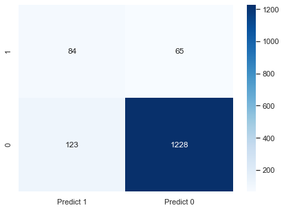

```python
print("Confusion Matrix")
cm=metrics.confusion_matrix(y3_test, predicted3, labels=[1, 0])

df_cm = pd.DataFrame(cm, index = [i for i in ["1","0"]],
                  columns = [i for i in ["Predict 1","Predict 0"]])
plt.figure(figsize = (7,5))
sns.heatmap(df_cm, annot=True, cmap='Blues', fmt='g');
```

**Bernoulli Naive Bayes**

```python
X4_train, X4_test, y4_train, y4_test = train_test_split(X_scaled, y, test_size=0.30, random_state=1)
```

```python
model4 = BernoulliNB()
model4.fit(X4_train, y4_train)
print('Score of the Naive bayes (Bernoulli) Model for its training dataset: ',model4.score(X4_train, y4_train))
print('Score of the Naive bayes (Bernoulli) Model for its testing dataset: ',model4.score(X4_test,y4_test))
```

```
Score of the Naive bayes (Bernoulli) Model for its training dataset:  0.9214285714285714
Score of the Naive bayes (Bernoulli) Model for its testing dataset:  0.9053333333333333
```

```python
# make predictions
expected4 = y4_test
predicted4 = model4.predict(X4_test)
# summarize the fit of the model
print(metrics.classification_report(expected4, predicted4))
```

```
              precision    recall  f1-score   support

         0.0       0.92      0.97      0.95      1351
         1.0       0.55      0.28      0.37       149

    accuracy                           0.91      1500
   macro avg       0.74      0.63      0.66      1500
weighted avg       0.89      0.91      0.89      1500
```

```
Confusion Matrix
```

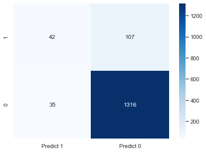

```python
print("Confusion Matrix")
cm=metrics.confusion_matrix(y4_test, predicted4, labels=[1, 0])

df_cm = pd.DataFrame(cm, index = [i for i in ["1","0"]],
                  columns = [i for i in ["Predict 1","Predict 0"]])
plt.figure(figsize = (7,5))
sns.heatmap(df_cm, annot=True, cmap='Blues', fmt='g');
```

*Inference*

- Bernoulli NB gives a better model accuracy in comparison to the Gaussian Naive Bayes with the given dataset
- The recall and f1 score is a bit compromised in the prior

Plotting ROC curves for all the models build to see which has the best ROC

```
No Skill: ROC AUC=0.500
Logistic: ROC AUC=0.786
Logistic (Target Balancing- Undersampling): ROC AUC=0.891
Logistic (Target Balancing- Oversampling): ROC AUC=0.912
Gaussian Naive Bayes: ROC AUC=0.736
Bernoulli Naive Bayes: ROC AUC=0.628
```

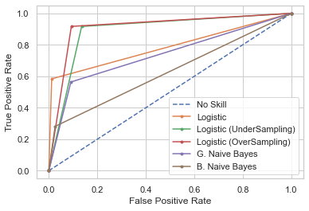

```python
ns_probs = [0 for _ in range(len(y_test))]
ns_auc = roc_auc_score(y_test, ns_probs)
lr_auc = roc_auc_score(y_test, y_preds)
lrus_auc = roc_auc_score(y1_test, y1_preds)
lros_auc = roc_auc_score(y2_test, y2_preds)
nb_auc = roc_auc_score(y3_test, predicted3)
nbb_auc = roc_auc_score(y4_test, predicted4)

#find ROC score:
print('No Skill: ROC AUC=%.3f' % (ns_auc))
print('Logistic: ROC AUC=%.3f' % (lr_auc))
print('Logistic (Target Balancing- Undersampling): ROC AUC=%.3f' % (lrus_auc))
print('Logistic (Target Balancing- Oversampling): ROC AUC=%.3f' % (lros_auc))
print('Gaussian Naive Bayes: ROC AUC=%.3f' % (nb_auc))
print('Bernoulli Naive Bayes: ROC AUC=%.3f' % (nbb_auc))


# calculate roc curves
ns_fpr, ns_tpr, _ = roc_curve(y_test, ns_probs)
lr_fpr, lr_tpr, _ = roc_curve(y_test, y_preds)
lrus_fpr, lrus_tpr, _ = roc_curve(y1_test, y1_preds)
lros_fpr, lros_tpr, _ = roc_curve(y2_test, y2_preds)
nb_fpr, nb_tpr, _ = roc_curve(y3_test, predicted3)
nbb_fpr, nbb_tpr, _ = roc_curve(y4_test, predicted4)

# plot the roc curve for the model
plt.plot(ns_fpr, ns_tpr, linestyle='--', label='No Skill')
plt.plot(lr_fpr, lr_tpr, marker='.', label='Logistic')
plt.plot(lrus_fpr, lrus_tpr, marker='.', label='Logistic (UnderSampling)')
plt.plot(lros_fpr, lros_tpr, marker='.', label='Logistic (OverSampling)')
plt.plot(nb_fpr, nb_tpr, marker='.', label='G. Naive Bayes')
plt.plot(nbb_fpr, nbb_tpr, marker='.', label='B. Naive Bayes')



# axis labels
plt.xlabel('False Positive Rate')
plt.ylabel('True Positive Rate')

plt.legend()
```

*Inference*

**6.Conclusion**

- The best model came out to be Logistic Regression with the balanced target (Undersampled and oversampled data)
- The imbalance in the target can have inflence on the analysis.
- There was no significant use of Zipcodes in the dataset
- It can be suggested that the potential loan customers are with high spends and mortgage
- More features like income, no of dependents etc could be added for more understanding of the dataset and better inference of potential customers for loan